# Analysing orthogonal poplar stem profiles, using nested model approach

# Access to the data

```r
library(tidyverse)
library(magrittr)
library(broom)

source("DataWrangling.R")
```

*** following: https://www.jstatsoft.org/article/view/v056i05/ ***

# Level 1 - ‘TreeId’

We fit an initial two-level HLM using crossection height (Sect_height) to explain differences between profiles (delta_d) allowing for a random intercept for each tree:  
*** $ delta_d ~ Sect_height + (1 | TreeId) ***

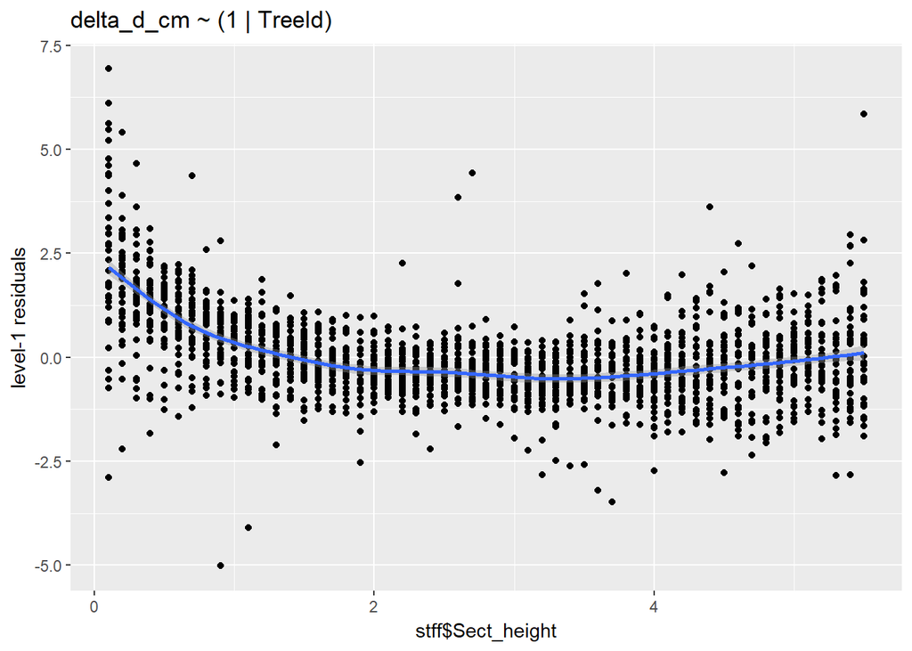

```r
library(lme4)

mc <- function(frml, ...) {
# evaluate the model (specified as formula) and produce the residulas control plot
  fm <- stff %>%  lmer(data = ., frml, ... )
  p <- qplot(x = stff$Sect_height, y = residuals(fm),
        geom = c("point", "smooth")) + ylab("level-1 residuals") +
    ggtitle(paste0(as.expression(frml)))
  print(p)
return(fm)
}

# prova senza Treat e senza Sect_height
fm00 <- mc(delta_d_cm ~  (1 | TreeId))
```

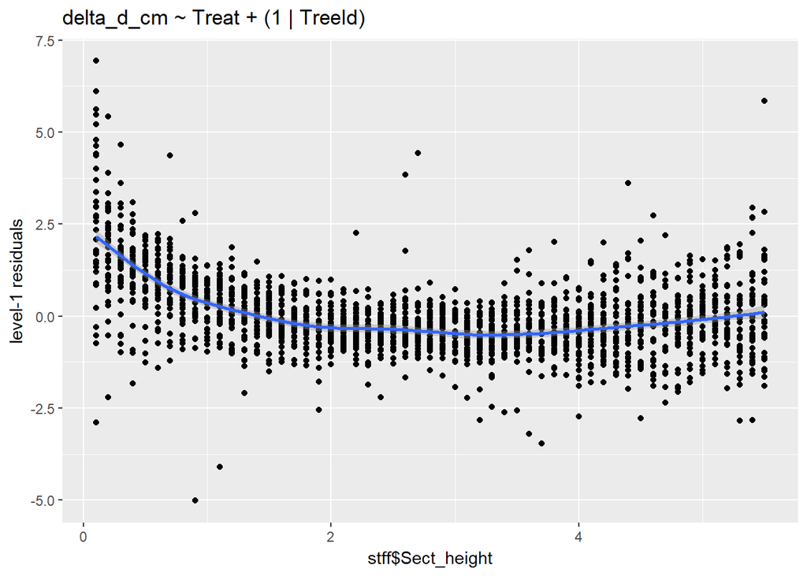

```r
# prova con Treat ma senza Sect_height
fm10 <- mc(delta_d_cm ~ Treat + (1 | TreeId))
```

```r
summary(fm10)
```

```
Linear mixed model fit by REML ['lmerMod']
Formula: delta_d_cm ~ Treat + (1 | TreeId)
   Data: .

REML criterion at convergence: 5942

Scaled residuals:
    Min      1Q  Median      3Q     Max
-4.7039 -0.6199 -0.1528  0.4410  6.4969

Random effects:
 Groups   Name        Variance Std.Dev.
 TreeId   (Intercept) 1.209    1.100
 Residual             1.139    1.067
Number of obs: 1953, groups:  TreeId, 36

Fixed effects:
            Estimate Std. Error t value
(Intercept)  1.87466    0.32015   5.855
TreatV450    0.05661    0.45277   0.125
TreatV500   -0.23917    0.45287  -0.528

Correlation of Fixed Effects:
          (Intr) TrV450
TreatV450 -0.707
TreatV500 -0.707  0.500
```

```r
# Treat  non ha effetto!
summary(fm00)
```

```
Linear mixed model fit by REML ['lmerMod']
Formula: delta_d_cm ~ (1 | TreeId)
   Data: .

REML criterion at convergence: 5942.7

Scaled residuals:
    Min      1Q  Median      3Q     Max
-4.7012 -0.6202 -0.1523  0.4425  6.4984

Random effects:
 Groups   Name        Variance Std.Dev.
 TreeId   (Intercept) 1.156    1.075
 Residual             1.139    1.067
Number of obs: 1953, groups:  TreeId, 36

Fixed effects:
            Estimate Std. Error t value
(Intercept)   1.8139     0.1808   10.03
```

## The two orthogonal profiles are significantly different: 1.8 cm +/- 10%

```r
anova(fm10, fm00)
```

```
refitting model(s) with ML (instead of REML)
```

|  | Df | AIC | BIC | logLik | deviance | Chisq | Chi Df | Pr(>Chisq) |
| --- | --- | --- | --- | --- | --- | --- | --- | --- |
| fm00 | 3 | 5947.09 | 5963.822 | -2970.545 | 5941.09 | NA | NA | NA |
| fm10 | 5 | 5950.57 | 5978.456 | -2970.285 | 5940.57 | 0.520544 | 2 | 0.7708419 |

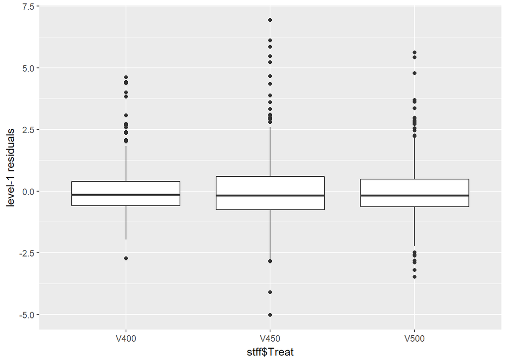

```r
# Contributo di Treat non significativo
qplot(x = stff$Treat, y = residuals(fm10),
      geom = c("boxplot")) + ylab("level-1 residuals")
```

```r
# residui distribuiti male e non a zero di media per Treat
```

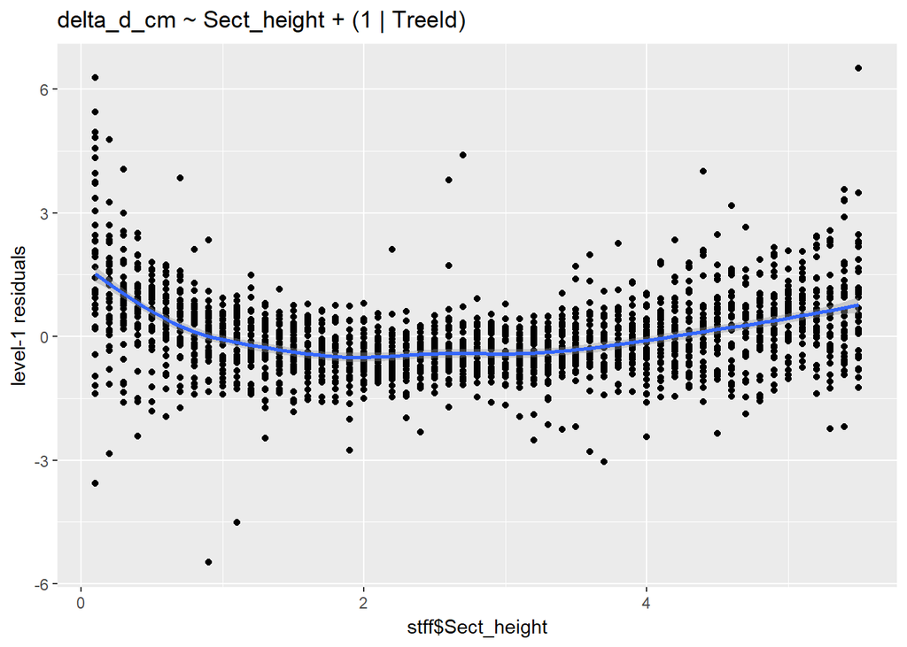

```r
# prova CON Sect_height,   lineare
fm01 <- mc(delta_d_cm ~ Sect_height + (1 | TreeId))
```

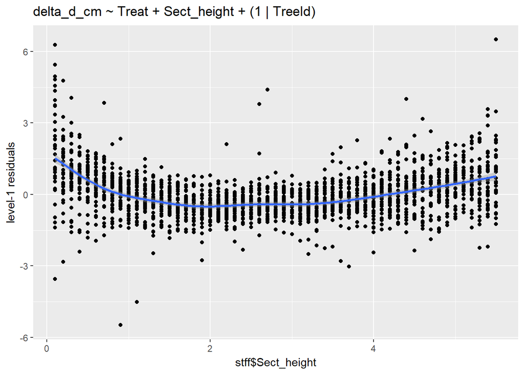

```r
fm11 <- mc(delta_d_cm ~ Treat + Sect_height + (1 | TreeId))
```

```r
anova(fm11, fm01)
```

```
refitting model(s) with ML (instead of REML)
```

|  | Df | AIC | BIC | logLik | deviance | Chisq | Chi Df | Pr(>Chisq) |
| --- | --- | --- | --- | --- | --- | --- | --- | --- |
| fm01 | 4 | 5679.246 | 5701.554 | -2835.623 | 5671.246 | NA | NA | NA |
| fm11 | 6 | 5682.618 | 5716.081 | -2835.309 | 5670.618 | 0.6273965 | 2 | 0.7307395 |

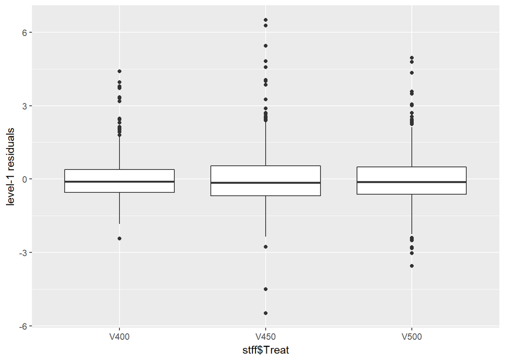

```r
qplot(x = stff$Treat, y = residuals(fm11),
      geom = c("boxplot")) + ylab("level-1 residuals")
```

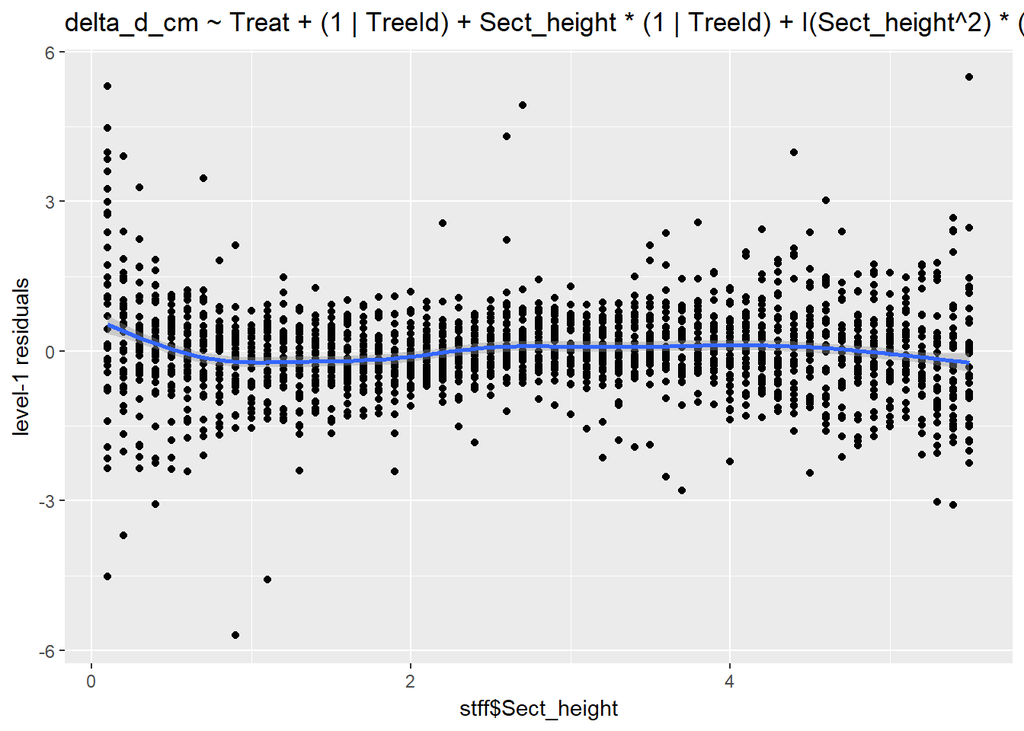

```r
# residui ancora etreoscedastici

# prova CON Sect_height, parabolica
fm12 <- mc(delta_d_cm ~ Treat + (1 | TreeId) + Sect_height *(1 | TreeId) + I(Sect_height^2)* (1 | TreeId))
```

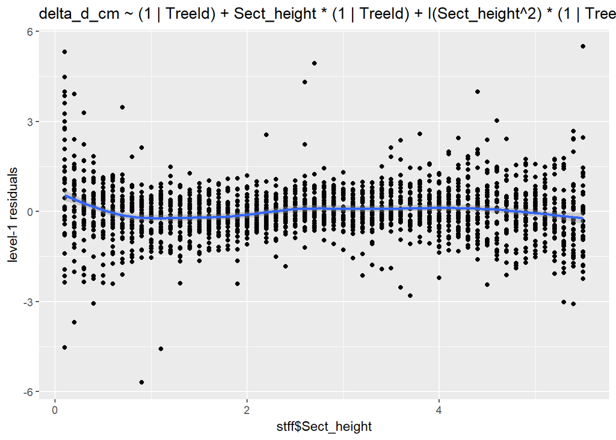

```r
fm02 <- mc(delta_d_cm ~ (1 | TreeId) + Sect_height *(1 | TreeId) + I(Sect_height^2)* (1 | TreeId))
```

```r
anova(fm02,fm12)
```

```
refitting model(s) with ML (instead of REML)
```

|  | Df | AIC | BIC | logLik | deviance | Chisq | Chi Df | Pr(>Chisq) |
| --- | --- | --- | --- | --- | --- | --- | --- | --- |
| fm02 | 7 | 5200.795 | 5239.835 | -2593.397 | 5186.795 | NA | NA | NA |
| fm12 | 9 | 5204.249 | 5254.443 | -2593.124 | 5186.249 | 0.5464193 | 2 | 0.7609333 |

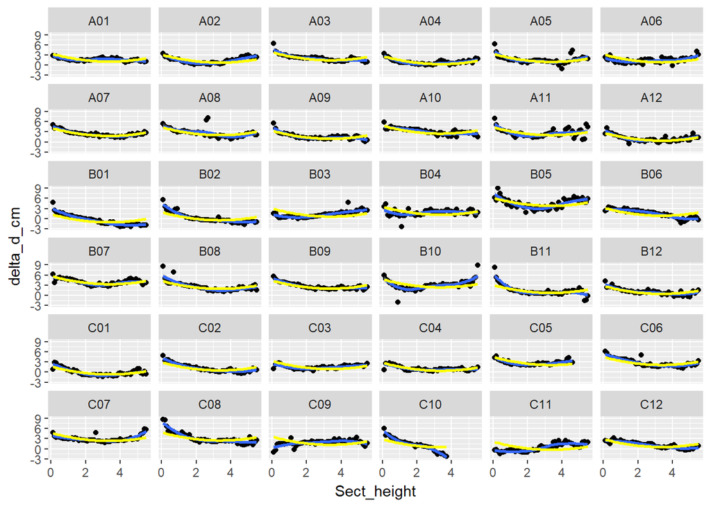

```r
stff %>% ggplot() +
  geom_point(aes(x = Sect_height, y = delta_d_cm)) +
  geom_smooth(aes(x = Sect_height, y = delta_d_cm)) +
  geom_line(aes(x = Sect_height, y = fitted(fm12)), color = "yellow", size = 1) +
  facet_wrap(~TreeId)
```

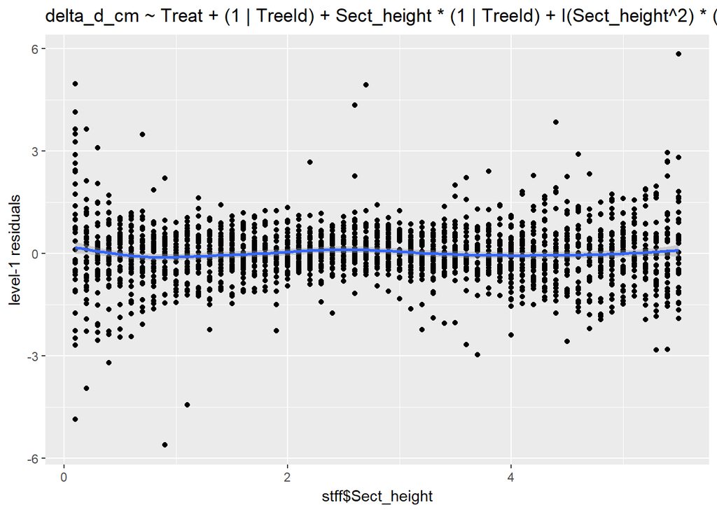

```r
# prova CON Sect_height, al cubo (con RML=T, non converge!)
fm13 <- mc(delta_d_cm ~ Treat + (1 | TreeId)
           + Sect_height *(1 | TreeId)
           + I(Sect_height^2)* (1 | TreeId)
           + I(Sect_height^3)* (1 | TreeId)
           , REML = F)
```

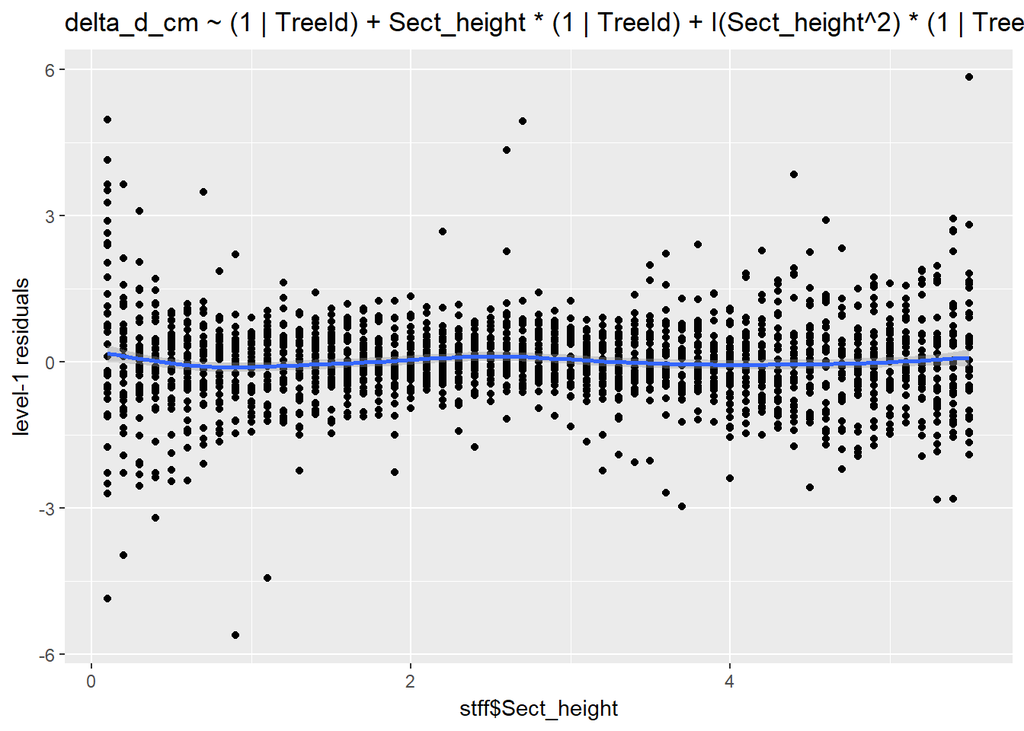

```r
fm03 <- mc(delta_d_cm ~ (1 | TreeId)
           + Sect_height *(1 | TreeId)
           + I(Sect_height^2)* (1 | TreeId)
           + I(Sect_height^3)* (1 | TreeId)
           , REML = F)
```

```r
anova(fm03,fm13)
```

|  | Df | AIC | BIC | logLik | deviance | Chisq | Chi Df | Pr(>Chisq) |
| --- | --- | --- | --- | --- | --- | --- | --- | --- |
| fm03 | 9 | 5150.993 | 5201.187 | -2566.496 | 5132.993 | NA | NA | NA |
| fm13 | 11 | 5154.443 | 5215.791 | -2566.221 | 5132.443 | 0.5501288 | 2 | 0.7595232 |

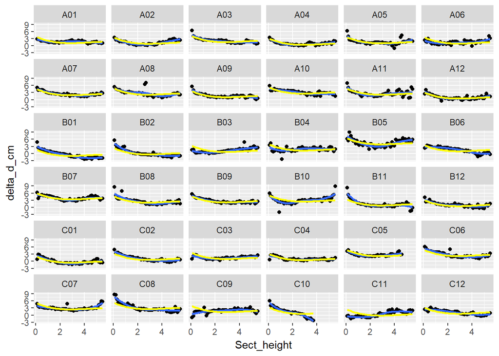

```r
# l'effetto di Treat, non si manifesta in nessun modo!!
#  Pr(>Chisq) = 0.761  !! Conferma, non si vede differenza


stff %>% ggplot() +
  geom_point(aes(x = Sect_height, y = delta_d_cm)) +
  geom_smooth(aes(x = Sect_height, y = delta_d_cm)) +
  geom_line(aes(x = Sect_height, y = fitted(fm13)), color = "yellow", size = 1) +
  facet_wrap(~TreeId)
```

In an exploratory setting we would go through this cycle of residual analysis, identification of explanatory variables, and model fitting multiple times until a satisfactory level-1 model is found (Tukey 1977).

# Level-2 residuals

The level-2, or random effects, residuals are defined as Zibi or, more commonly, bi. Following an upward residual analysis we prefer the use of EB residuals at level 2 (insted of LS residuals). The level-2 residuals are used to * identify additional explanatory variables that contribute significantly to the model, * check linearity of the level-2 explanatory variables, and * investigate whether the level-2 residuals follow a normal distribution. To obtain the level-2 EB residuals from model fm3, we use the following code:

```r
resid2_fm12 <- HLMresid(object = fm13, level = "TreeId")
head(resid2_fm12)
```

|  | (Intercept) | (Intercept) | (Intercept) | (Intercept) |
| --- | --- | --- | --- | --- |
| A01 | -0.005603814 | -0.05534186 | -0.05495312 | -0.06592019 |
| A02 | -0.014895308 | -0.14710232 | -0.14606902 | -0.17522022 |
| A03 | 0.006472235 | 0.06391817 | 0.06346918 | 0.07613581 |
| A04 | -0.028426347 | -0.28073146 | -0.27875951 | -0.33439193 |
| A05 | -0.008099787 | -0.07999147 | -0.07942958 | -0.09528145 |
| A06 | -0.012045868 | -0.11896197 | -0.11812634 | -0.14170097 |

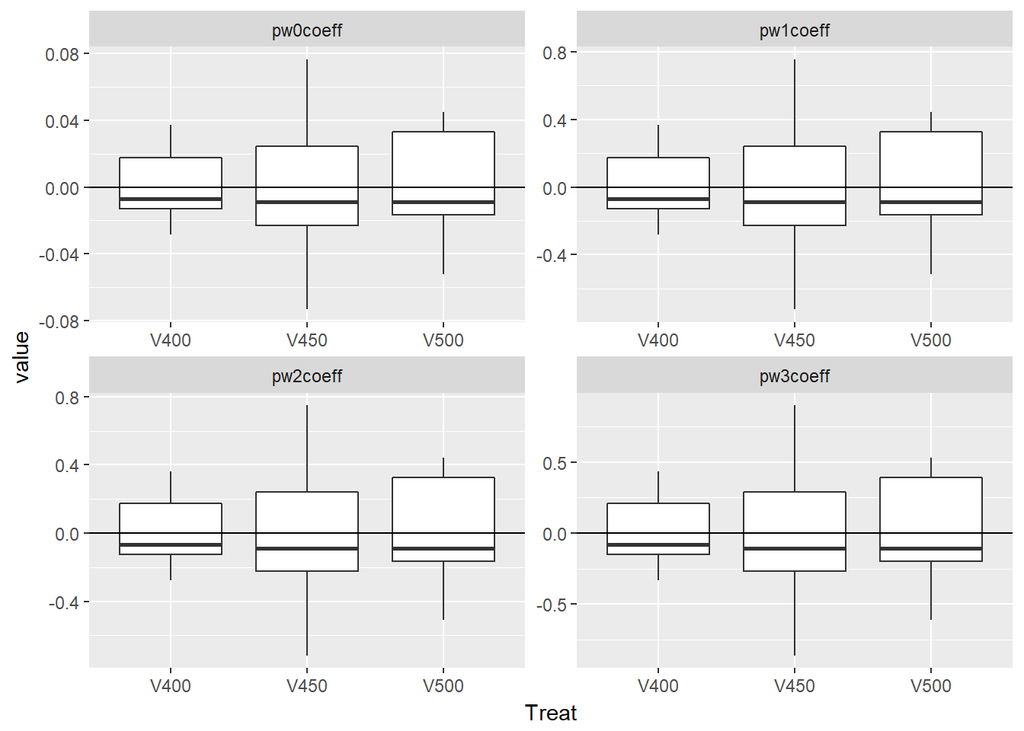

```r
res <- stff %>%
  select(Treat, TreeId) %>%
  unique() %>%
  inner_join(mutate(resid2_fm12, TreeId = row.names(resid2_fm12))) %>%
  select(1:2, pw0coeff = 3, pw1coeff = 4, pw2coeff = 5, pw3coeff = 6) %>%
  gather(param, value,  3:6)
# paste0("pw",0:3,"coeff = ", 3:6, collapse=", ")

ggplot(res, aes(x = Treat, y = value)) +
  geom_boxplot() +
  geom_hline(yintercept = 0) +
  facet_wrap(~param, scales = "free")
```

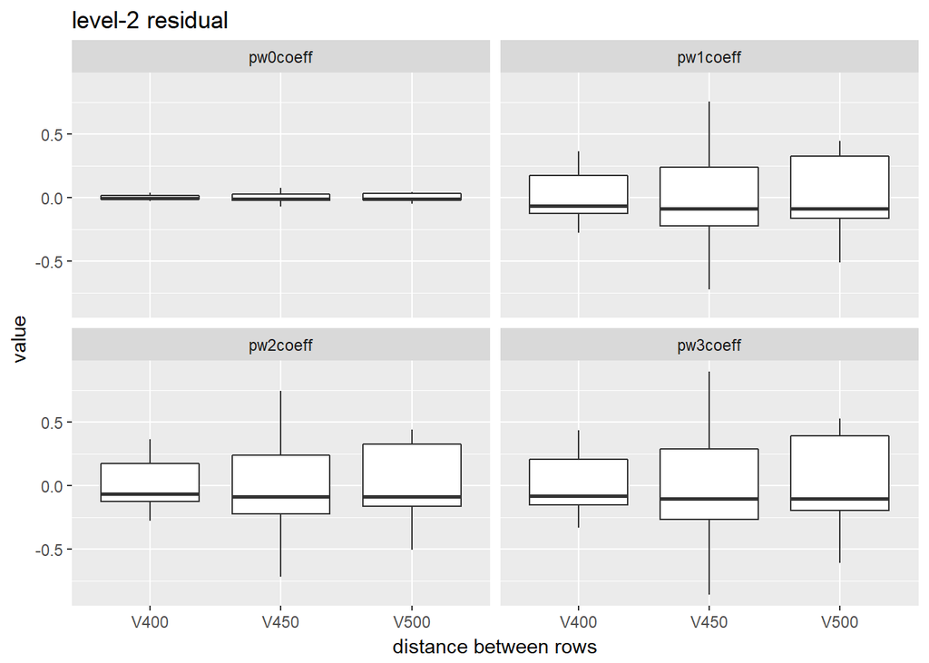

```r
res %$%
  qplot(x = Treat, y = value, geom = 'boxplot', facets = ~param,
  xlab = 'distance between rows', main = 'level-2 residual')
```

# Opzione non esplorata:

Forse è più semplice dividere il range di Sect_height in 3 parti < 1 e >4 (zeri dell’intepolazione generale dei residui dal modello lineare) ed utilizzare quats avriabile come ulteriore ‘effetto fisso’. A quel punto l’approssimazione lineare di delta_d=f(Sect_heiht) dovrebbe essere presentabile.

[rmarkdown::render(“PdP_HLM3.Rmd”, output_file = “PdP_HLM3.html”, encoding=“UTF-8”)]